# Análisis Matemático¶

## 7ta Semana (03/02/2020) - Aplicación del concepto de función en ML

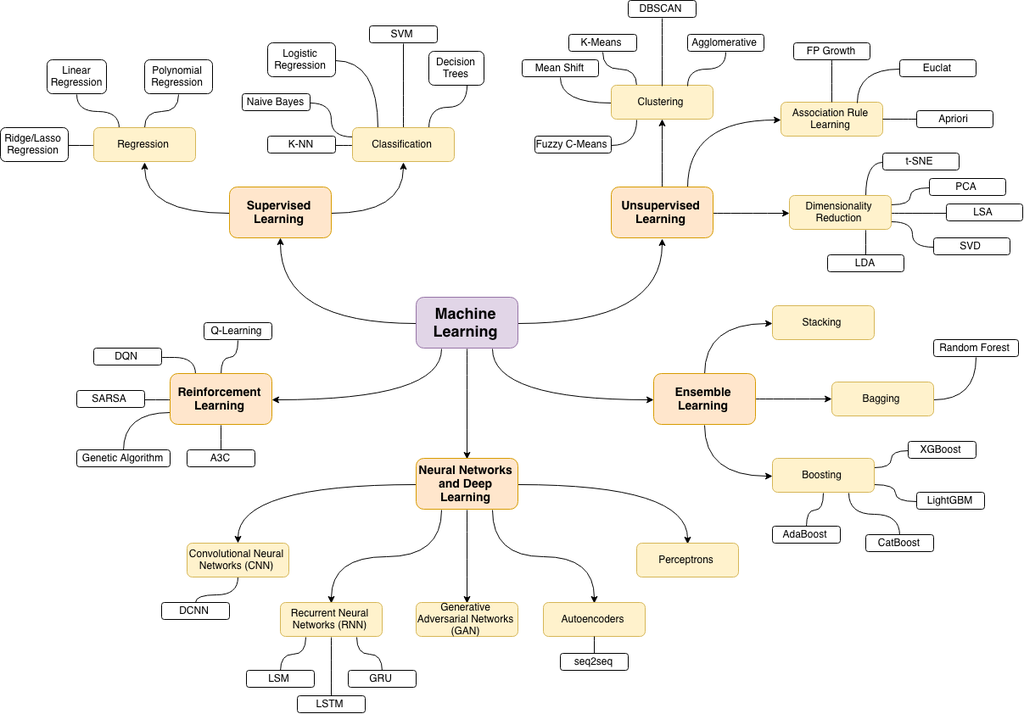

## Esto era regresión lineal.

Aprendizaje supervisado porque le damos el valor de Y. Sabemos la salida antes de entrenar.

Lineal porque es Continuo el valor de la salida, números reales.

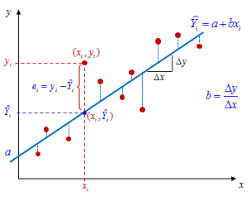

## Función matemática:

Una función matemática es una relación que se establece entre dos conjuntos, a través de la cual a cada elemento del primer conjunto se le asigna un único elemento del segundo conjunto o ninguno.

Se puede representar gráficamente. pero no necesariamente.

Se puede expresar a tavéz de una ecuación matemática, pero no necesariamente.

https://www.aprendemachinelearning.com/regresion-logistica-con-python-paso-a-paso/

## La Regresión Logística es un Algoritmo Supervisado y se utiliza para clasificación.

## Binaria

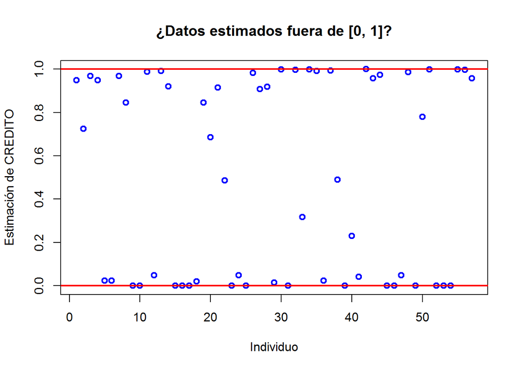

### A partir de los datos entreno el algoritmo.

```python
from sklearn.linear_model import LogisticRegression

neigh = LogisticRegression()

#[height, weight, shoe_size]
X = [[181, 80, 44], [177, 70, 43], [160, 60, 38], [154, 54, 37], [166, 65, 40], [190, 90, 47], [175, 64, 39],
     [177, 70, 40], [159, 55, 37], [171, 75, 42], [181, 85, 43]]

Y = ['male', 'male', 'female', 'female', 'male', 'male', 'female', 'female', 'female', 'male', 'male']
#Y = ['Juan', 'Pepe', 'Veroni', 'Mariee', 'Karl', 'Dann', 'Silvin', 'Andrea', 'female', 'male', 'male']

neigh.fit(X, Y)
```

```
LogisticRegression()
```

```python
X[1]
```

```
[177, 70, 43]
```

### Luego de entrenar puedo usar la red para predecir.

```python
prediction = neigh.predict([[170, 65, 40]])
print(prediction)
```

```
['female']
```

```python
import matplotlib.pyplot as plt
import seaborn as sns
from sklearn import metrics

cm = metrics.confusion_matrix(Y, neigh.predict(X))
print(cm)
```

```
[[5 0]
 [0 6]]
```

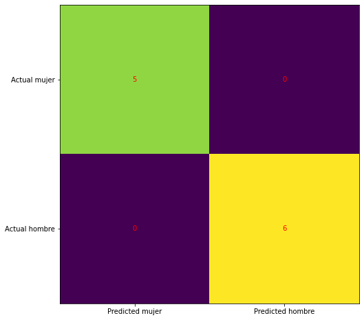

```python
fig, ax = plt.subplots(figsize=(8, 8))
ax.imshow(cm)
ax.grid(False)
ax.xaxis.set(ticks=(0, 1), ticklabels=('Predicted mujer', 'Predicted hombre'))
ax.yaxis.set(ticks=(0, 1), ticklabels=('Actual mujer', 'Actual hombre'))
ax.set_ylim(1.5, -0.5)
for i in range(2):
    for j in range(2):
        ax.text(j, i, cm[i, j], ha='center', va='center', color='red')
plt.show()
```

https://www.aprendemachinelearning.com/clasificar-con-k-nearest-neighbor-ejemplo-en-python/

## K-Nearest-Neighbor es un algoritmo basado en instancia de tipo supervisado de Machine Learning. Puede usarse para clasificar nuevas muestras (valores discretos) o para predecir (regresión, valores continuos).

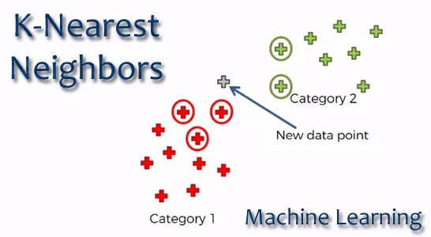

```python
from sklearn.neighbors import KNeighborsClassifier


neigh = KNeighborsClassifier(n_neighbors=3)

#[height, weight, shoe_size]
X = [[181, 80, 44], [177, 70, 43], [160, 60, 38], [154, 54, 37], [166, 65, 40], [190, 90, 47], [175, 64, 39],
     [177, 70, 40], [159, 55, 37], [171, 75, 42], [181, 85, 43]]

Y = ['male', 'male', 'female', 'female', 'male', 'male', 'female', 'female', 'female', 'male', 'male']

neigh.fit(X, Y)

prediction = neigh.predict([[170, 85, 43]])

print(prediction)
```

```
['male']
```

https://www.aprendemachinelearning.com/arbol-de-decision-en-python-clasificacion-y-prediccion/

## Los arboles de decisión son representaciones gráficas de posibles soluciones a una decisión basadas en ciertas condiciones, es uno de los algoritmos de aprendizaje supervisado más utilizados en machine learning y pueden realizar tareas de clasificación o regresión (acrónimo del inglés CART).

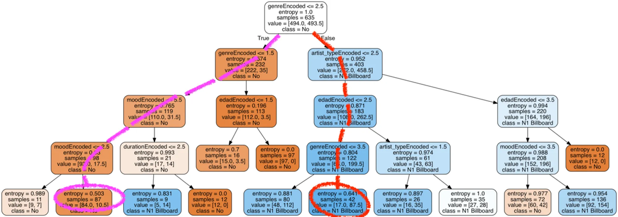

```python
from sklearn import tree


clf = tree.DecisionTreeClassifier()

#[height, weight, shoe_size]
X = [[181, 80, 44], [177, 70, 43], [160, 60, 38], [154, 54, 37], [166, 65, 40], [190, 90, 47], [175, 64, 39],
     [177, 70, 40], [159, 55, 37], [171, 75, 42], [181, 85, 43]]

Y = ['male', 'male', 'female', 'female', 'male', 'male', 'female', 'female', 'female', 'male', 'male']

clf = clf.fit(X, Y)

prediction = clf.predict([[190, 85, 43]])

print(prediction)
```

```
['male']
```

https://www.aprendemachinelearning.com/random-forest-el-poder-del-ensamble/

## Random Forest es un tipo de Ensamble en Machine Learning en donde combinaremos diversos árboles -ya veremos cómo y con qué características- y la salida de cada uno se contará como “un voto” y la opción más votada será la respuesta del Bosque Aleatorio.

## Random Forest, al igual que el árbol e decisión, es un modelo de aprendizaje supervisado para clasificación (aunque también puede usarse para problemas de regresión).

```python
from sklearn.ensemble import RandomForestClassifier

clf = RandomForestClassifier(n_estimators=2)

#[height, weight, shoe_size]
X = [[181, 80, 44], [177, 70, 43], [160, 60, 38], [154, 54, 37], [166, 65, 40], [190, 90, 47], [175, 64, 39],
     [177, 70, 40], [159, 55, 37], [171, 75, 42], [181, 85, 43]]

Y = ['male', 'male', 'female', 'female', 'male', 'male', 'female', 'female', 'female', 'male', 'male']

clf = clf.fit(X, Y)

prediction = clf.predict([[190, 85, 43]])

print(prediction)
```

```
['male']
```

```python
from sklearn.naive_bayes import GaussianNB


gnb = GaussianNB()

X = [[181, 80, 44], [177, 70, 43], [160, 60, 38], [154, 54, 37], [166, 65, 40], [190, 90, 47], [175, 64, 39],
     [177, 70, 40], [159, 55, 37], [171, 75, 42], [181, 85, 43]]

Y = ['male', 'male', 'female', 'female', 'male', 'male', 'female', 'female', 'female', 'male', 'male']

gnb = gnb.fit(X, Y)

prediction = gnb.predict([[190, 70, 43]])

print(prediction)
```

```
['male']
```